# Composition of Unemployment by Reason

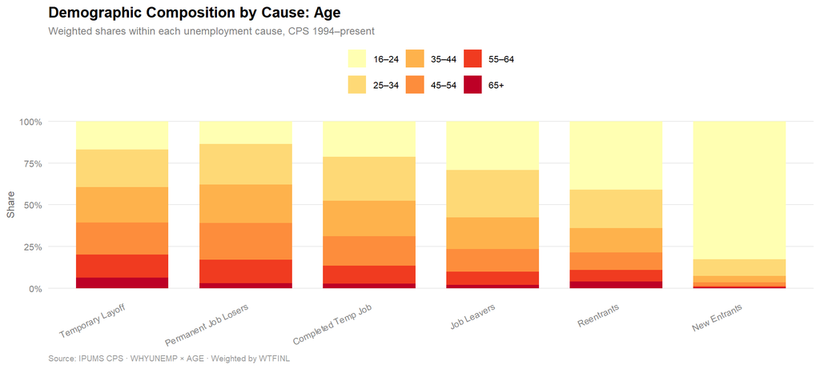

Figure 29: Age composition of each unemployment cause (weighted, 1994–present).

```r
weighted_by(cps, "age_group") |>
  ggplot(aes(x = cause, y = n, fill = group)) +
  geom_col(position = "fill", width = 0.75) +
  scale_y_continuous(labels = percent_format()) +
  scale_fill_brewer(palette = "YlOrRd") +
  labs(
    title = "Demographic Composition by Cause: Age",
    subtitle = "Weighted shares within each unemployment cause, CPS 1994–present",
    x = NULL, y = "Share", fill = NULL,
    caption = "Source: IPUMS CPS · WHYUNEMP × AGE · Weighted by WTFINL"
  ) +
  theme_report +
  theme(axis.text.x = element_text(angle = 25, hjust = 1))
```

**Full History**

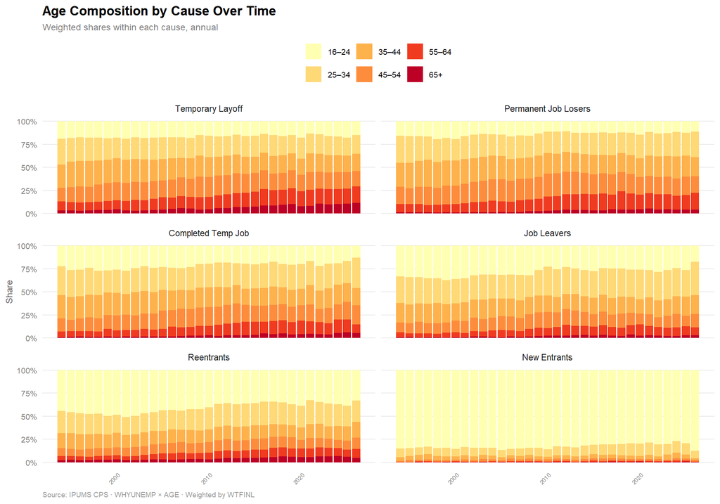

Figure 30: Age composition of each unemployment cause over time (annual, 1994–present).

```r
weighted_by_year(cps, "age_group") |>
  ggplot(aes(x = YEAR, y = share, fill = group)) +
  geom_col(width = 0.9, position = "stack") +
  facet_wrap(~ cause, ncol = 2) +
  scale_y_continuous(labels = percent_format()) +
  scale_fill_brewer(palette = "YlOrRd") +
  labs(
    title = "Age Composition by Cause Over Time",
    subtitle = "Weighted shares within each cause, annual",
    x = NULL, y = "Share", fill = NULL,
    caption = "Source: IPUMS CPS · WHYUNEMP × AGE · Weighted by WTFINL"
  ) +
  theme_report +
  theme(axis.text.x = element_text(angle = 45, hjust = 1, size = 6))
```

**Recent Detail**

[figure not shown]

```r
weighted_by_month(cps |> filter(date >= cps_recent_start), "age_group") |>
  ggplot(aes(x = date, y = share, fill = group)) +
  geom_col(width = 22, position = "stack") +
  facet_wrap(~ cause, ncol = 2) +
  scale_y_continuous(labels = percent_format()) +
  scale_x_date(date_breaks = "3 months", date_labels = "%b\n'%y") +
  scale_fill_brewer(palette = "YlOrRd") +
  labs(
    title = "Age Composition by Cause — Recent Detail",
    subtitle = paste0("Monthly weighted shares, ", format(cps_recent_start, "%Y"), "–present"),
    x = NULL, y = "Share", fill = NULL,
    caption = "Source: IPUMS CPS · WHYUNEMP × AGE · Weighted by WTFINL"
  ) +
  theme_report +
  theme(axis.text.x = element_text(size = 6))
```

New entrants are overwhelmingly young: over 60% are aged 16–24, which is natural since most first-time job seekers are teenagers or recent graduates. Temporary layoffs skew toward prime-age workers (25–54), reflecting industries like construction and manufacturing where temporary furloughs are common. Re-entrants have a broader age distribution, with a notable share of workers aged 35–54 returning after time out of the labor force — consistent with parents re-entering after caregiving.

The next set of plots rescales each age share by its contemporaneous share in the **civilian labor force**. Formally, for demographic group $g$ and unemployment cause $c$:

$$\text{Representation Ratio}_{g,c,t} =
\frac{\text{Share of cause } c \text{ accounted for by group } g}
{\text{Share of the labor force accounted for by group } g}$$

A value above 1 means the group is overrepresented in that unemployment cause relative to its labor-force share; a value below 1 means it is underrepresented. For example, if workers aged 16–24 make up 30% of new entrants but only 12% of the labor force, the ratio is $30/12 = 2.5$, meaning they are represented at roughly 2.5 times their labor-force share.